# R Notebook

Execute the code by clicking the *Run* button within the chunk or by placing your cursor inside it and pressing *Cmd+Shift+Enter*.

This is a simple Bayesian subsidence model customized for Tonian succession in Svalbard. It should yield similar results to those in the manuscript by Halverson et al. (submitted Earth Science Frontiers, 10/2021)

This code uses the Rethinking package by Richard McElreath, so before running it, you you may need first to install the “rethinking” package

This version of the model uses a quadratic approximation (QUAP) to solve for the posterior, both to take into account uncertainty on ages and their stratigraphic positions within the Svalbard succession, as well as to implement the rule of superposition, it runs a bootstrapping routine to fill the final posterior with data based on many different combinations of ages/height positions.

```r
graphics.off() # This closes all of R's graphics windows.
rm(list=ls())  # Careful! This clears all of R's memory!
```

Now we need to load the necessary packages to run the codes, meaning you will need to install these packages if you haven’t already.

install.packages(“rethinking”) install.packages(“dplyr”)

```r
library(rethinking)
library(dplyr)
```

Now we will load the data (which you need to have in the same folder as this file), sort it, and look at it just to make sure it looks OK

```r
hAgeDat <- read.csv("height_age.csv")
dat <- select(hAgeDat, height, range, age, ageUnc, type) # Now select the columns we want
dat <- arrange(dat, height) # Sort the data so it is easier to read
print(dat)
```

| height | range | age | ageUnc | type |
| --- | --- | --- | --- | --- |
| 250 | 150 | 815.29 | 0.50 | uniform |
| 430 | 40 | 811.51 | 0.25 | normal |
| 450 | 20 | 810.70 | 3.15 | normal |
| 1125 | 200 | 788.70 | 0.47 | uniform |
| 1675 | 100 | 775.10 | 0.50 | uniform |
| 1850 | 100 | 759.90 | 1.20 | normal |
| 1960 | 20 | 752.70 | 2.75 | normal |
| 2060 | 10 | 737.50 | 4.80 | normal |
| 2097 | 20 | 739.90 | 3.05 | normal |
| 2175 | 40 | 735.25 | 0.44 | normal |

[output cut: 1 more lines]

```r
numdat <- nrow(dat)
```

We will also read in another csv files with the heights of interest for this study. These are basically the formation boundaries, along with the start and end of the Bitter Springs Anomaly.

```r
plot_heights <- read.csv("plot_heights.csv")
plot_heights <- arrange(plot_heights, height) # Sort the data to ensure that it is in order
print(plot_heights)
```

| height | name |
| --- | --- |
| 462.0 | "start Bitter Springs Anomaly" |
| 660.0 | "base Svanbergfjellet Fm." |
| 780.2 | "end Bitter Springs Anomaly" |
| 1126.0 | "base Draken Fm." |
| 1439.0 | "base of Backlundtoppen Fm." |
| 1894.1 | "base of Russøya Mb." |
| 1961.0 | "base Polarisbreen Gp." |
| 2094.0 | "start Russøya Anomaly" |
| 2130.0 | "base Petrovbreen Mb." |

```r
l <- length(plot_heights$height)
```

Now we will plot the data now, with 95% error bars, along with the key boundaries of interest

```r
# set the limits for plotting
ymin <- signif((min(dat$age)), digits=1)
ymax <- signif((max(dat$age)), digits=1)+50
xmax <- signif((max(dat$height)), digits=1)+500
# We'll plot the original data with error bars just to see what it looks like]

# plot the original data
plot(dat$height, dat$age, xlim=c(0, xmax), ylim=c(ymax, ymin),
     xlab="Height (m)", ylab="Age (Ma)", main="Age versus Height", col=rgb(0,0,1), pch=1, cex=1.5, lwd=2)
grid(nx=27, ny=23, col = "lightgray", lty = "dotted", lwd = par("lwd"))
```

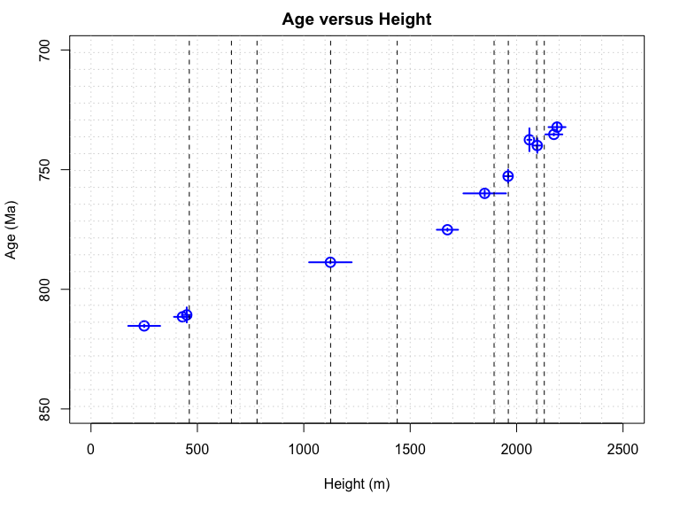

```r
# plot error bars

for ( i in 1:numdat ) {
  ci_age <- dat$age[i] + c(-1,1)*dat$ageUnc[i]
  if (dat$type[i] == "normal"){
    ci_height <- dat$height[i] + c(-1,1)*dat$range[i]
  } else {
    ci_height <- dat$height[i] + c(-1,1)*dat$range[i]/2
  }
  x <- dat$height[i]
  y <- dat$age[i]
  lines( c(x,x) , ci_age, lwd=2, col=rgb(0,0,1))
  lines( ci_height, c(y,y), lwd=2, col=rgb(0,0,1))
}

# the following code plots the key boundaries of interest
for ( i in 1:l){
  abline(v=plot_heights$height[i], lty=2)
}
```

We have plotted the height uncertainties in the graph above at the 95% level so that it is comparable to the age uncertainty. Note that we are treating the height uncertainty as Gaussian. We have chosen a Gaussian probability density function (pdf) instead of uniform pdf because we’ve made the ‘best guess’ for the actual correlation of the ages to the Svalbard stratigraphy and assume the chances diminish away from this best guess, which is appropriate for tie-point uncertainties (Lougheed and Obrochta, 2019). Also, we want there to be a non-zero chance that this fit is incorrect beyond that uncertainty range. The 95% uncertainty will be accounted for in the bootstrapping routine, where the SD will equal half of the uncertainties shown in the table.

First we will define initial parameters for the thermal subsidence model, which are from Allen and Allen (2013). None of these parameters are treated as variable (that is, to be modeled here). However, it would be relatively straightforward to add these to the model. Note, some of these parameters are not actually used in the model but have been left in because they are used in other similar models.

```r
y_c     = 35000   # Initial crustal thickness in m               [m]
y_l     = 110000  # Initial lithospheric thickness in m          [m]
rho_m0  = 3330    # Density of the mantle at 0 degrees C         [kg/m^3]
rho_c0  = 2800    # Density of the crust at 0 degrees C          [kg/m^3]
rho_w   = 1030    # Density of water                             [kg/m^3]
rho_s   = 2600    # Density of sediments                         [kg/m^3]
alpha_v = 3.28E-5 # Volumetric coefficient of thermal expansion  [1/K]
Tm      = 1333    # Temperature of the mantle                    [C]
kappa   = 1e-6   # Thermal diffusivity                          [m^2/s]

# time_my = 0:150  # Time range                                    [my]
time_s  = 365*24*3600*1e6        # Time in seconds

#E0w      = 4*y_l*rho_m0*alpha_v*Tm/(pi^2*(rho_m0-rho_w)) # correction for water-loaded subsidence
E0s      = 4*y_l*rho_m0*alpha_v*Tm/(pi^2*(rho_m0-rho_s)) # correction for sediment-loaded subsidence. This is what we are using here.
tau     = y_l^2/(pi^2*kappa) # Thermal decay constant
```

```r
beta_prior <- 1.3 # based on Halverson et al. (2018)
beta_prior_sigma <- 0.2 # a loosely prescribed prior. See also Figure 5 in main text
drift_prior <- 817 # based on Halverson et al. (2018)
drift_prior_sigma <- 5 # a loosely prescribed prior
sigma_prior <- 10 # a loosely prescribed prior

set.seed(150)

bootnumber <- 7500  # this is the number of samples we want in the posterior (i iterations)
post <- data.frame(matrix(ncol=3,nrow=bootnumber)) # this sets up a dataframe to hold the posterior values
colnames(post) = c("a","b","sigma")
boot_heights <- vector("numeric") # to store the bootstrapped heights
boot_ages <- vector("numeric")  # to store the bootstrapped ages
agey <- vector("numeric")
heightx <- vector("numeric")
```

Now for the routine. The way this works is that it will run iterations, sampling randomly from the age and height distributions we’ve provided for each distribution, then running a Bayesian analysis (a quadratic approximation) for each data set and adding the a randomly selected result from the individual posterior distribution to the ‘composite’ posterior distribution, stored in a dataframe.

```r
for (i in 1:bootnumber){

# Initialize the dataframe for each bootstrap session
boot_frame <- data.frame(matrix(ncol=2, nrow=numdat))
colnames(boot_frame) <- c("height", "age")

  for (j in 1:numdat){
    boot_frame$age[j] <- rnorm(1, mean=dat$age[j], sd=dat$ageUnc[j]/2)
    if (dat$type[j] == "normal"){
    boot_frame$height[j] <- rnorm(1, mean=dat$height[j], sd=dat$range[j]/2)
    } else {
      boot_frame$height[j] <- runif(1, min=(dat$height[j]-dat$range[j]/2), max=(dat$height[j]+dat$range[j]/2))
    }
  }

# Now ensure that all of the all of the samples obey superposition. Note that this is different from some other Bayesian models, which would reject any combination of heights/ages in which one age is out of place. Here, we want to keep all of the data points that do obey, because otherwise, due to large uncertainties on certain ages that lie close to each other, this would make most randomly chosen sample combinations invalid. But also, from a geological perspective, this approach allows for disregarding correlated age-height ages that are inaccurate.

# In order to weed out disobeying data points, we need to cycle through the bootstrapped data and simply compare adjacent data points. This routine might need to be modified for a scenario where there are more closely spaced data.

# First we will order the data by height

age_boot <- vector("numeric")
height_boot <- vector("numeric") # initialize the vectors that will be used in bootstrapping
boot_frame <- arrange(boot_frame, height)
counter <- 1


# Now we will set this up to run in opposite directions on alternate iterations so that it doesn't preferentially exclude one data point every time. Basically for odd numbers of 'i' in the 'for' sequence, the algorithm starts with the lowest stratigraphic level then cycles up section. Then for even numbers of 'i', it starts with the highest sample and works down section.

if(i %% 2 != 0){
  height_boot[counter] <- boot_frame$height[counter]
  age_boot[counter] <- boot_frame$age[counter]
  counter <- counter+1
  for (j in 2:numdat){
    if (boot_frame$age[j] < boot_frame$age[j-1]){
      height_boot[counter] <- boot_frame$height[j]
      age_boot[counter] <- boot_frame$age[j]
      counter <- counter+1
      }
  }
} else {
  height_boot[counter] <- boot_frame$height[numdat]
  age_boot[counter] <- boot_frame$age[numdat]
  counter <- counter+1
    for (j in numdat:2){
      if (boot_frame$age[j-1] > boot_frame$age[j]){
        height_boot[counter] <- boot_frame$height[j-1]
        age_boot[counter] <- boot_frame$age[j-1]
        counter <- counter+1
      }
    }
  i1 <- order(height_boot)
  height_boot <- height_boot[i1]
  age_boot <- age_boot[i1]
}

boot_heights <- append(boot_heights, height_boot) # store the bootstrapped heights for plotting later
boot_ages <- append(boot_ages, age_boot) # store the bootstrapped ages for plotting later

# Now put the bootstrapped data into a single dataframe, which will be fed to the quadratic approximation (quap) model

bootdat <- expand.grid(height=height_boot)
bootdat <- cbind(bootdat, age=age_boot)

# Now do a quadratic Bayesian fit. Note that the start values have been fixed. If these vary too much, quap won't run...

mLin <- quap(
  alist(
    age ~ dnorm(mu,sigma),
    mu <- a + tau/time_s*log(1-(height/E0s*pi/b)/sin(pi/b)),
    a ~ dnorm(drift_prior,drift_prior_sigma),
    b ~ dnorm(beta_prior,0.2),
    sigma ~ dunif(0,10)
  ),
  start=list(a=817.5, b=1.29, sigma=3),
  data=bootdat
  )

# precis(mLin, prob=0.95) # if you want to look at a summary of the results

post1 <- extract.samples(mLin, n=1)
post1 <- as.data.frame(t(post1))
post1 <- as.numeric(post1[1,])
post[i,] <- post1

# We'll set our next prior based on the current posterior. Not that we do not yet use the uncertainties for the priors. The reason is that this causes the uncertainty to shrink progressively, which is not realistic or what we are aiming for.

# cf <- as.data.frame(precis(mLin)) # use this code if you want to put the precis values into a data.frame
drift_prior <- post1[1]
beta_prior <- post1[2]


}
```

Now we will plot a series of viable curves (in gray) for different sets of bootstrapped data, along with the bootstrapped data points themselves (in red), and finally the original data and uncertainties. Note that the way the model is set up, each curve that is plotted is not based on the mean of the parameters issued by each individual Bayesian analysis, but rather is a random sample from the parameter posterior distributions. This provides a more plausible spread in possible values for these parameters, hence a more realistic HPDI. The approach doesn’t have any real effect on the median values of the parameters. On rare occasions some of the fits are quite extreme and produces NaNs. However, even in this event, the data should plot.

```r
# And plot some results and the original data
plot(NULL, xlim=c(0, xmax), ylim=c(ymax, ymin),
     xlab="Height (m)", ylab="Age (Ma)", main="Age versus Height", pch=1, cex=1.5, lwd=2)
grid(nx=27, ny=23, col = "lightgray", lty = "dotted", lwd = par("lwd"))
```

```r
for (i in 1:bootnumber){
  curve(post$a[(i-1)*10+1]+tau/time_s*log(1-(x/E0s*pi/post$b[(i-1)*10+1])/sin(pi/post$b[(i-1)*10+1])), 0, 2300, lwd=1, col=rgb(0.9,0.9,0.9,0.5), add=TRUE)
}

# plot the bootstrapped points onto plot
points(boot_heights, boot_ages, pch=46, col=rgb(1,0,0,0.4), cex=2)
```

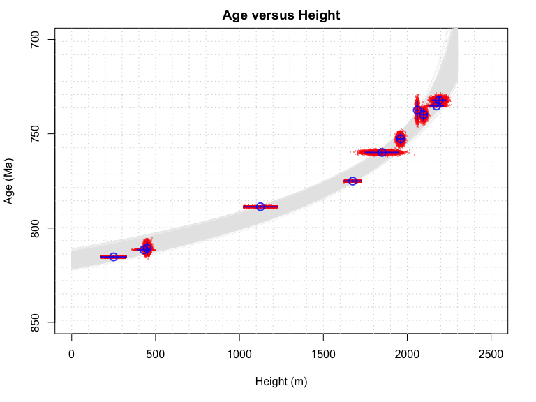

```r
# plot the original data and uncertainties
points(dat$height, dat$age, xlim=c(0, xmax), ylim=c(ymax, ymin),
     xlab="Height (m)", ylab="Age (Ma)", main="Age versus Height", pch=1, cex=1.5, lwd=2, col=rgb(0,0,1,0.8))

# error bars
for ( i in 1:numdat ) {
  ci_age <- dat$age[i] + c(-1,1)*dat$ageUnc[i]
  if (dat$type[i] == "normal"){
    ci_height <- dat$height[i] + c(-1,1)*dat$range[i]
  } else {
    ci_height <- dat$height[i] + c(-1,1)*dat$range[i]/2
  }
  x <- dat$height[i]
  y <- dat$age[i]
  lines( c(x,x) , ci_age, lwd=2, col=rgb(0,0,1,0.8))
  lines( ci_height, c(y,y), lwd=2, col=rgb(0,0,1,0.8))
}
```

This Figure shows the posterior fits (gray lines) to the bootstrapped data (red dots), superposed on the original sample data and uncertainties.

Here we summarize the ‘composite’ posterior data. Note that we use the median rather than the mean since some distributions will not be perfectly Guassian.

```r
a_median<- median(post$a)
a_HPDI <- HPDI(post$a, prob=0.95)
a_plus <- a_HPDI[2] - a_median
a_minus <- a_median - a_HPDI[1]
b_median <- median(post$b)
b_HPDI <- HPDI(post$b, prob=0.95)
b_plus <- b_HPDI[2] - b_median
b_minus <- b_median - b_HPDI[1]
```

Here we look at the posterior distributions of our y-intercept (= onset of rifting, or rift-drift transition) and beta parameters.

```r
hist(post$b, breaks = 30, main = NULL, xlab="beta", ylab=NULL, yaxt = "n" )
  title("Posterior beta", adj = 0.05, line = -2)
```

```r
abline(v=b_median, col="red", lwd=2)
abline(v=b_HPDI[1], col="blue", lty=2)
```

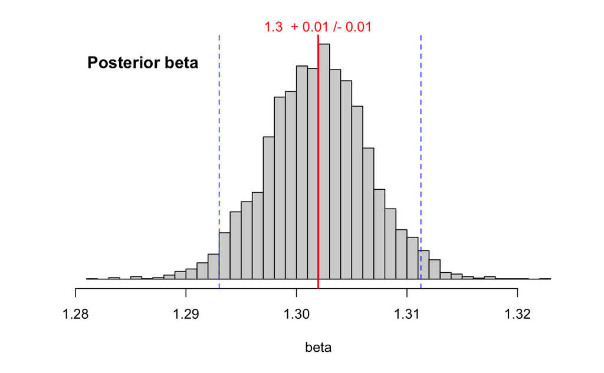

```r
abline(v=b_HPDI[2], col="blue", lty=2)
mtext(side=3, at=b_median,
     paste(round(b_median, 2), " +", round((b_HPDI[2]-b_median),2), "/-", round((b_median-b_HPDI[1]),2)),
     col = "red",
     cex = 1)
```

```r
hist(post$a, breaks = 30, main = NULL, xlab="age of rift-drift transition", ylab=NULL, yaxt = "n")
  title("Posterior rift-drift", adj = 0.05, line = -2)
```

```r
abline(v=a_median, col="red", lwd=2)
abline(v=a_HPDI[1], col="blue", lty=2)
```

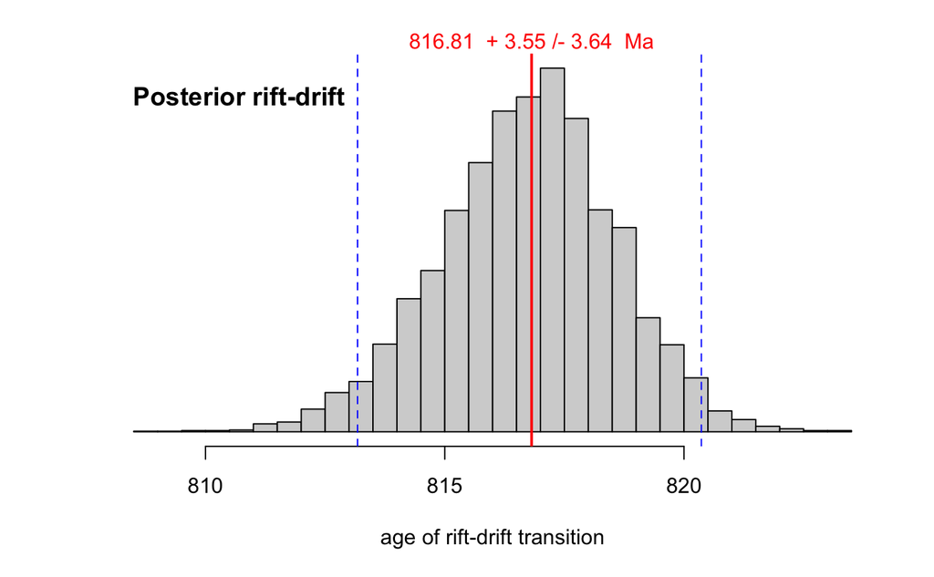

```r
abline(v=a_HPDI[2], col="blue", lty=2)
mtext(side=3, at=a_median,
     paste(round(a_median, 2), " +", round((a_HPDI[2]-a_median),2), "/-", round((a_median-a_HPDI[1]),2), " Ma"),
     col = "red",
     cex = 1)
```

And here we set up these results to be added to the legend of the next figure

```r
beta <- round(b_median, 2) %>% as.character
betap <- round(b_plus, 2) %>% as.character
betam <- round(b_minus, 2) %>% as.character
a <- round(a_median, 2) %>% as.character
ap <- round(a_plus, 2) %>% as.character
am <- round(a_minus, 2) %>% as.character
```

This routine calculates an age and uncertainty for every meter (or 5 m) in the stratigraphic column and exports a file with this information

```r
height.num <- 2130 # This is the height for the top of the Russøya Formation
spacing = 5 # m
HPDI_matrix <- matrix(nrow=2, ncol=(height.num/spacing+1))
height.seq <- seq( from=0, to=height.num, by=spacing)
AgeHeight <- as.data.frame(height.seq, colnames = "height")
colnames(AgeHeight)[colnames(AgeHeight) == "height.seq"] <- "height"

for (i in 1:(height.num/spacing+1)){
  mu <- post$a+tau/time_s*log(1-(height.seq[i]/E0s*pi/post$b)/sin(pi/post$b))
  mu.median <- median(mu)
  mu.HPDI <- HPDI(mu, prob=0.95)
  HPDI_matrix[1,i] <- mu.HPDI[1]
  HPDI_matrix[2,i] <- mu.HPDI[2]
  AgeHeight$age_median[i] <- round(mu.median,2)
  AgeHeight$age_min[i] <- round(mu.HPDI[1],2)
  AgeHeight$age_max[i] <- round(mu.HPDI[2], 2)
  AgeHeight$plus[i] <- round((mu.HPDI[2]-mu.median),2)
  AgeHeight$minus[i] <- round((mu.median-mu.HPDI[1]),2)
}

write.csv(AgeHeight, "Age_Heights5m_Calibrated_bootmodel.csv")
```

The following routine is similar but generates the ages and uncertainties for every height for which we have data

```r
dset <- read.csv('Svalbard_composite.csv')
# clean it up and sort it
dset <- na.omit(dset)
dset <- arrange(dset, height) # Sort the data to ensure that it is in order
len_dset <- length(dset$height)

for (i in 1:(len_dset)){
  mu <- post$a+tau/time_s*log(1-(dset$height[i]/E0s*pi/post$b)/sin(pi/post$b))
  mu.median <- median(mu)
  mu.HPDI <- HPDI(mu, prob=0.95)
  dset$age_median[i] <- round(mu.median,2)
  dset$age_min[i] <- round(mu.HPDI[1],2)
  dset$age_max[i] <- round(mu.HPDI[2], 2)
}

write.csv(dset, "Svalbard_composite_with-ages.csv")
```

The following imports the heights for the Sr isotope data composite from Svalbard and generates ages and uncertainties for each data point

```r
Srdset <- read.csv('Sr_composite.csv')
Srdset <- arrange(Srdset, height) # Sort the data to ensure that it is in order
len_dset <- length(Srdset$height)

for (i in 1:(len_dset)){
  mu <- post$a+tau/time_s*log(1-(Srdset$height[i]/E0s*pi/post$b)/sin(pi/post$b))
  mu.median <- median(mu)
  mu.HPDI <- HPDI(mu, prob=0.95)
  Srdset$age_median[i] <- round(mu.median,2)
  Srdset$age_min[i] <- round(mu.HPDI[1],2)
  Srdset$age_max[i] <- round(mu.HPDI[2], 2)
}
```

Now plot the original data again with the posterior fit.

```r
# plot the original data
plot(dat$height, dat$age, xlim=c(0, xmax), ylim=c(ymax, ymin),
     xlab="Height (m)", ylab="Age (Ma)", main="Age versus Height", pch=1, cex=1.5, lwd=2, col=rgb(0,0,1,0.5))

# plot error bars
for ( i in 1:numdat ) {
  ci_age <- dat$age[i] + c(-1,1)*dat$ageUnc[i]
  if (dat$type[i] == "normal"){
    ci_height <- dat$height[i] + c(-1,1)*dat$range[i]
  } else {
    ci_height <- dat$height[i] + c(-1,1)*dat$range[i]/2
  }
  x <- dat$height[i]
  y <- dat$age[i]
  lines( c(x,x) , ci_age, lwd=2, col=rgb(0,0,1,0.5))
  lines( ci_height, c(y,y), lwd=2, col=rgb(0,0,1,0.5))
}
```

```r
lines(AgeHeight$height, AgeHeight$age_median)
lines(AgeHeight$height, AgeHeight$age_min, col="lightgrey")
```

```r
lines(AgeHeight$height, AgeHeight$age_max, col="lightgrey")
shade(HPDI_matrix, height.seq)
```

```r
points(heightx, agey, pch=46, col="red", cex=2)

# now I will add some vertical lines for the formation boundaries and the beginning and end of the Bitter Springs anomaly
abline(v=0, lwd=2)
```

```r
abline(v=462, col="purple", lty=2, lwd=2)
abline(v=660)
```

```r
abline(v=780.2, col="purple", lty=2, lwd=2)
abline(v=1126)
```

```r
abline(v=1439.6)
abline(v=1894.1, col="green", lty=3, lwd=2)
```

```r
abline(v=1961, lwd=2)
abline(v=2094, col="purple", lty=2, lwd=2)
```

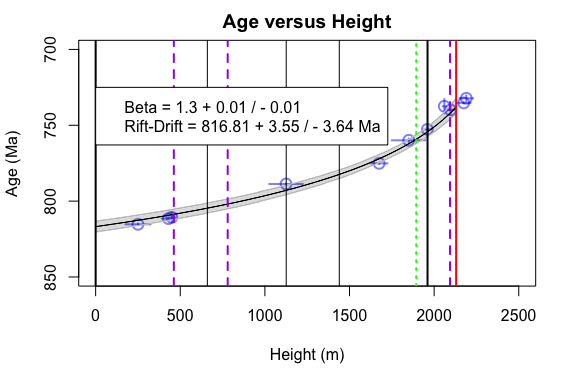

```r
abline(v=2130, lwd=2, col="red")
betab <- paste("Beta =", beta, "+", betap, "/ -", betam, sep = " ")
ir <- paste("Rift-Drift =", a, "+", ap, "/ -", am, "Ma", sep = " ")
legend(x=0,y=725,c(betab, ir))
```

```r
NA
NA
```

And we can plot the posterior age distribution for any height in the stratigraphc column. Here plot the ages for each of the vertical lines in the preceding figure on a single panel.

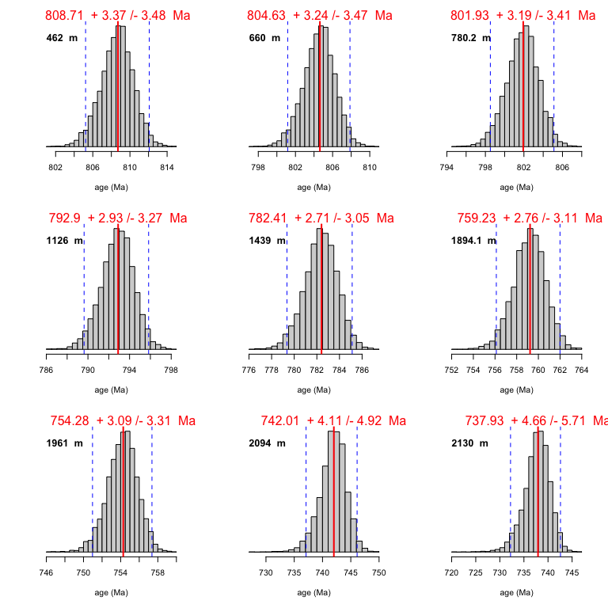

```r
nc <- round(l/3+0.49)
par(mfrow=c(nc,3))

for (k in 1:l){
  mu_temp <- post$a+tau/time_s*log(1-(plot_heights$height[k]/E0s*pi/post$b)/sin(pi/post$b))
  mu_median <- median(mu_temp)
  mu_HPDI <- HPDI(mu_temp, prob=0.95)
  plus <- round((mu_HPDI[2]-mu_median), 2) %>% as.character
  minus <- round((mu_median-mu_HPDI[1]), 2) %>% as.character
  main_label <- paste(as.character(plot_heights$height[k]), " m")
  hist(mu_temp, breaks = 20, main=NULL, xlab="age (Ma)", ylab=NULL, yaxt = "n")
  title(main_label, adj = 0.05, line = -2)
  abline(v=mu_median, col="red", lwd=2)
  abline(v=mu_HPDI[1], col="blue", lty=2)
  abline(v=mu_HPDI[2], col="blue", lty=2)
  mtext(side=3, at=mu_median,
     paste(round(mu_median, 2), " +", plus, "/-", minus, " Ma"),
     col = "red",
     cex = 1)
}
par(mfrow=c(1,1))
```

OK, now we use these results to estimate the duration of the Bitter Springs anomaly. This isn’t as simple as it might at first seem. One might think we could just randomly sample from each of the two distributions, subtract the differences, and compile a sufficiently large sample to estimate difference and uncertainty. We’ll do this first, but really, if you accept the model, this isn’t the right way to do it, because any two ages should be strongly correlated, and we won’t get correlated ages if we randomly sample from each distribution. So the better approach is to calculate the age difference from each posterior distribution.

Model 1:

```r
BSA_start <- post$a+tau/time_s*log(1-(plot_heights$height[1]/E0s*pi/post$b)/sin(pi/post$b))
BSA_end <- post$a+tau/time_s*log(1-(plot_heights$height[3]/E0s*pi/post$b)/sin(pi/post$b))
BSA_diff <- vector("numeric")

for (k in 1:10000){
  BSA_diff[k] <- sample(BSA_start, 1)-sample(BSA_end, 1)
}
median_BSA_diff <- median(BSA_diff)
HPDI_BSA_diff <- HPDI(BSA_diff, prob=0.95)
plus <- round((HPDI_BSA_diff[2]-median_BSA_diff), 2) %>% as.character
minus <- round((median_BSA_diff-HPDI_BSA_diff[1]), 2) %>% as.character
hist(BSA_diff, breaks=30, main=NULL, xlab="Time (My)", ylab=NULL, yaxt = "n")
abline(v=median(BSA_diff), col="red", lwd=2)
```

```r
abline(v=HPDI_BSA_diff[1], col="blue", lty=2)
abline(v=HPDI_BSA_diff[2], col="blue", lty=2)
```

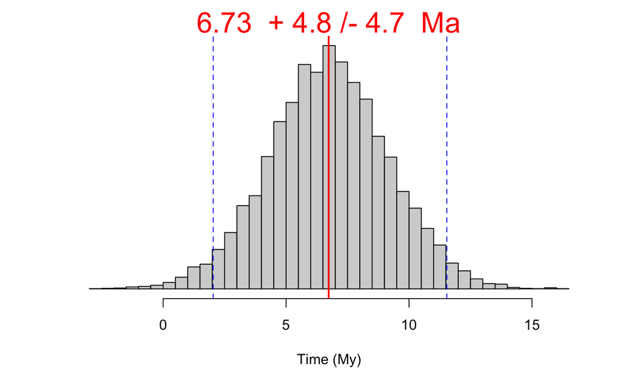

```r
mtext(side=3, at=median_BSA_diff,
     paste(round(median_BSA_diff, 2), " +", plus, "/-", minus, " Ma"),
     col = "red",
     cex = 2)
```

That’s a large uncertainty. Too large. The more appropriate way to infer the age uncertainty for the duration of the BSA is shown in the code and histogram below. Note the median isn’t that different from the previous example, but the uncertainty is over an order of magnitude better. Importantly, this is what we want in this case, because the ages for the onset and end of the BSA are strongly correlated, such that if one model output pushes one age in one direction, it will also push the other age in that direction by a similar magnitude.

```r
BSA_diff <- BSA_start - BSA_end
median_BSA_diff <- median(BSA_diff)
HPDI_BSA_diff <- HPDI(BSA_diff, prob=0.95)
plus <- round((HPDI_BSA_diff[2]-median_BSA_diff), 2) %>% as.character
minus <- round((median_BSA_diff-HPDI_BSA_diff[1]), 2) %>% as.character
hist(BSA_diff, breaks=30, main=NULL, xlab="Time (My)", ylab=NULL, yaxt = "n")
abline(v=median(BSA_diff), col="red", lwd=2)
```

```r
abline(v=HPDI_BSA_diff[1], col="blue", lty=2)
abline(v=HPDI_BSA_diff[2], col="blue", lty=2)
```

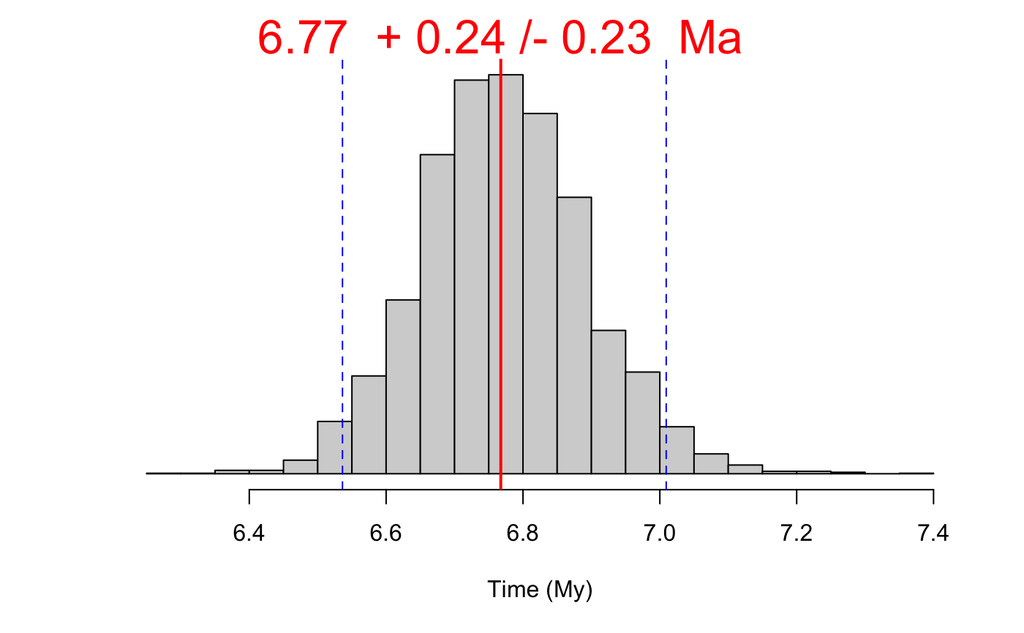

```r
mtext(side=3, at=median_BSA_diff,
     paste(round(median_BSA_diff, 2), " +", plus, "/-", minus, " Ma"),
     col = "red",
     cex = 2)
```

This figure shows the best estimate for duration of the Bitter Springs anomaly.

References:

Allen, P.A. and Allen, J.R., 2013. Basin Analysis: Principles and Applications to Petroleum Play Assessment (3rd Edition). Wiley-Blackwell, 632 pp.

Halverson, G. P., Porter, S. M., Gibson, T. M., 2018. Dating the late Proterozoic stratigraphic record. Emerging Topics in Life Science 2, 137-147.

Lougheed, B., Obrochta, S. P., 2019. A rapid, deterministic age-depth modeling routine for geological sequences with inherent depth uncertainty. Paleoceanography and Paleoclimatology 34, 122–133.

McElreath, R., 2020. Statistical Rethinking: A Bayesian Course with Examples in R and Stan, Second Edition. Chapman and Hall/CRC (Boca Raton), 612 pp.